# Simple Linear Regression

```r
# Load your libraries
library(car)
library(tidyverse)
library(ggplot2)
library(pander)
library(RColorBrewer)
library(leaflet)
library(plotly)
library(mosaic)
library(pander)
library(DT)

# Load your data after saving a csv file in your Data folder.
# You can use either
#   someName <- read.csv("../Data/YourDataFileName.csv", header=TRUE)
# or
#   library(readr)
carset <- read_csv("regression.csv")
#datatable(carset, options=list(lengthMenu = c(10,15,30)), extensions="Responsive")
# Don't forget to run "Session -> Set Working Directory -> To Source file location"
```

## Background

Data was taken from a variety of car models with statistics indicating their performances. Upon these statistics, the horsepower and acceleration of each model was also recorded and are also the 2 quantitative variables used for the analysis. The question is in seeing if there is a correlation between horsepower and acceleration. In other words, is there a relationship between the `horsepower` and the `acceleration` of a car?

The linear regression will be checked using the following equation:

$$\underbrace{Y_i}_\text{Acceleration} =
\overbrace{\beta_0}^\text{y-int} + \overbrace{\beta_1}^\text{slope}
\underbrace{X_i}_\text{Horsepower} + \epsilon_i \quad \text{where} \
\epsilon_i \sim N(0, \sigma^2)$$
The plot below displays the correlation between horsepower and acceleration. Although the plot does not portray a clear line, it can be noticed that there is a downward trend in the points of the plot. It appears that as the (average) horsepower of a car increases, the acceleration of a car decreases. However, to understand the relationship between horsepower and acceleration more, the following analysis is provided.

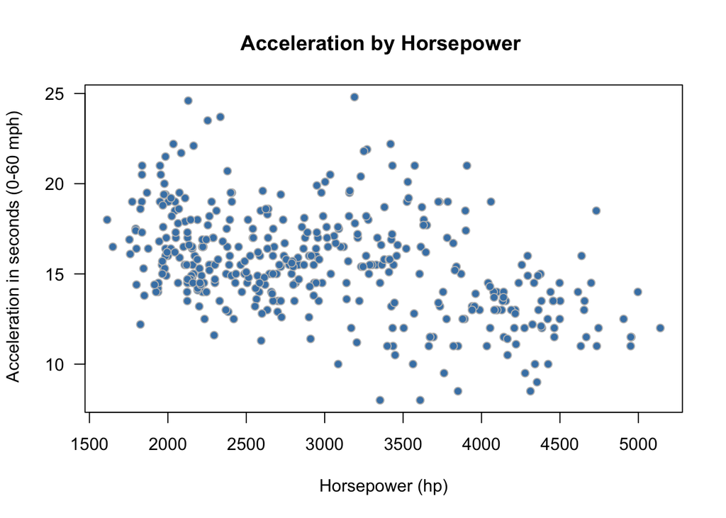

```r
plot(acceleration ~ horsepower, data=carset, pch=21, bg="steelblue", col="gray",
     xlab="Horsepower (hp)", ylab=" Acceleration in seconds (0-60 mph)",
     main="Acceleration by Horsepower ", las=1)
```

```r
pander(cor(carset$acceleration~ carset$horsepower))
```

*-0.4301*